# Loading the Data

```python
import pandas as pd
import numpy as np
import matplotlib.pyplot as plt
import matplotlib.image as mpimg
```

```python
train_data_df = pd.read_csv("TrainImgs.csv")
train_labels_df = pd.read_csv("TrainLabels.csv")
test_data_df = pd.read_csv("TestImgs.csv")
test_labels_df = pd.read_csv("TestLabels.csv")
```

```python
print(train_labels_df)
print(train_data_df)
```

```
        1
0       1
1       1
2       1
3       1
4       1
...    ..
13434  28
13435  28
13436  28
13437  28
13438  28

[13439 rows x 1 columns]
       0  0.1  0.2  0.3  0.4  0.5  0.6  0.7  0.8  0.9  ...  0.896  0.897  \
```

[output cut: 26 more lines]

```python
df_train = train_data_df.copy()
df_train['Label']=train_labels_df
df_test = test_data_df.copy()
df_test['Label']=test_labels_df
```

# Data shape

```python
print(df_train.shape[0],end="\n")
print(df_test.shape[0], end="\n")
```

```
13439
3359
```

# Count of Data and classes

```python
df_train['Label'].describe()
```

```
count    13439.000000
mean        14.501005
std          8.077509
min          1.000000
25%          8.000000
50%         15.000000
75%         21.500000
max         28.000000
Name: Label, dtype: float64
```

```python
df_train['Label'].nunique()
```

```
28
```

# Reshaping to show data

```python
df_train = train_data_df.copy()
df_train['Label']= train_labels_df

images = []
d = {1: 'أ', 2: 'ب', 3: 'ت', 4: 'ث', 5: 'ج', 6: 'ح', 7: 'خ', 8: 'د', 9: 'ذ', 10: 'ر', 11: 'ز', 12: 'س', 13: 'ش', 14: 'ص',
     15: 'ض', 16: 'ط', 17: 'ظ', 18: 'ع', 19: 'غ', 20: 'ف', 21: 'ق', 22: 'ك', 23: 'ل', 24: 'م', 25: 'ن', 26: 'ه', 27: 'و', 28: 'ي'}
```

# Plotting images and seeing the maximum and minimum ranges for the pixels

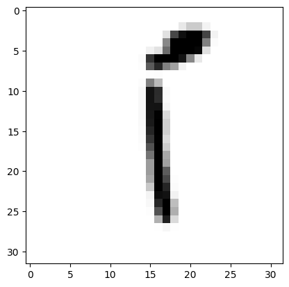

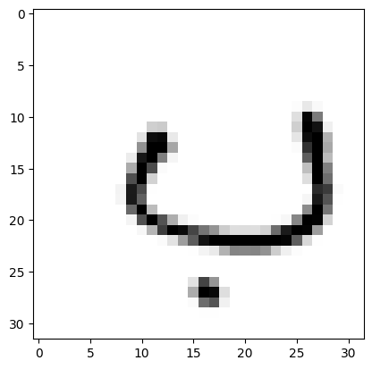

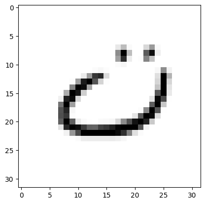

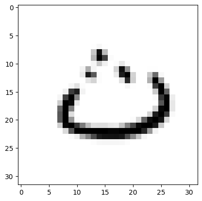

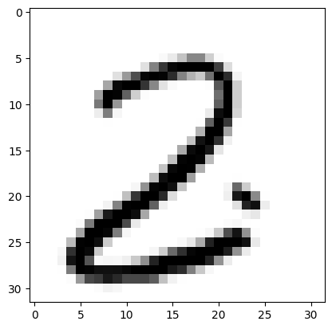

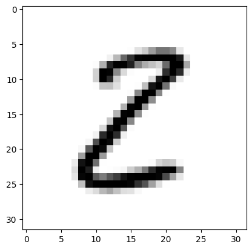

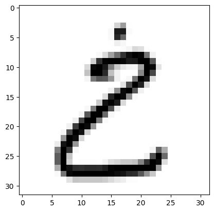

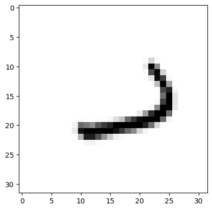

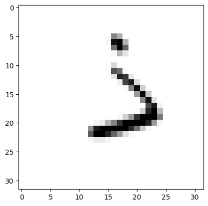

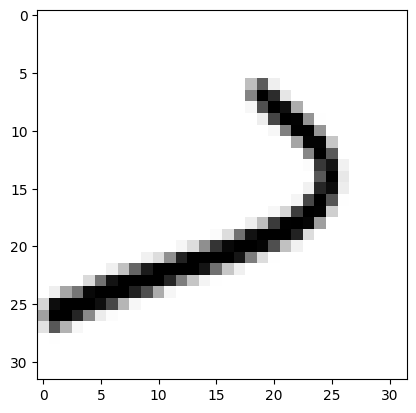

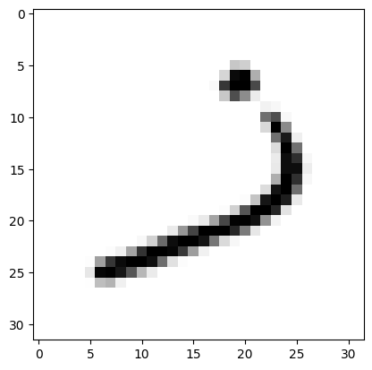

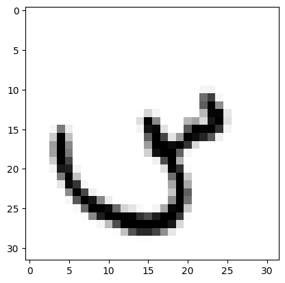

[16 more figures not shown]

```
255 0
```

```python
# fig = plt.figure(figsize=(16, 16))
images = []
for i in range(1, 29):
    img_arr = (df_train[df_train['Label'] == i]).apply(
        lambda x: np.array(x.iloc[:-1]).reshape(32, 32), axis=1)
    try:
        images.append(list(img_arr)[0])
    except:
        pass
for im in images:
    # fig.add_subplot(2,2,images.index(im))
    plt.imshow(im.transpose(),cmap='Greys')
    plt.show()
print(np.amax(images[0]),np.amin(images[0]))
```

```python
df_train = df_train [df_train['Label'] <=16]
df_test = df_test[df_test['Label'] <= 16]
```

# Class Counts

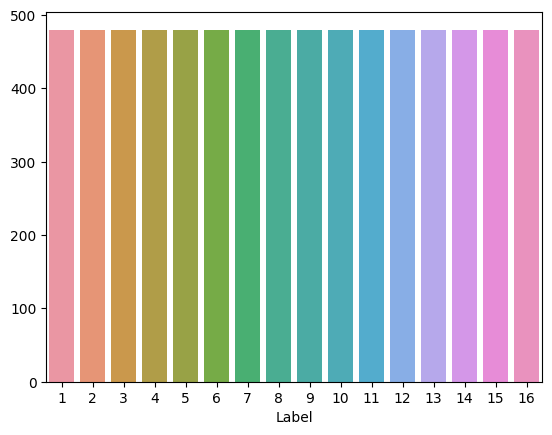

```python
from seaborn import barplot
plot_me = pd.DataFrame(df_train.groupby(['Label']).count().iloc(axis=1)[0]).transpose()

barplot(plot_me)
```

# Converting and Cutting off the mid gray colors

```python
def cutoff(x):
    return int(x!=0)
for k in df_train.keys():
    if (k !=  'Label'):
        df_train[k]=df_train[k].map(lambda x : cutoff(x))
for k in df_test.keys():
    if (k !=  'Label'):
        df_test[k]=df_test[k].map(lambda x : cutoff(x))
```

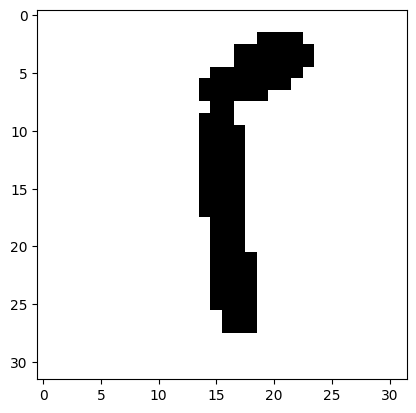

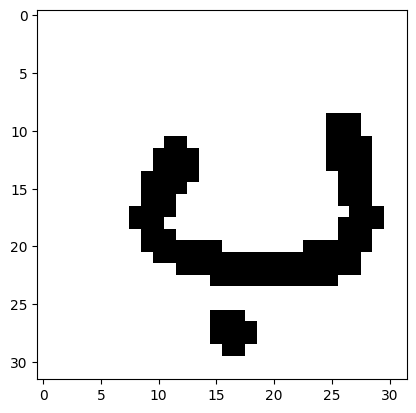

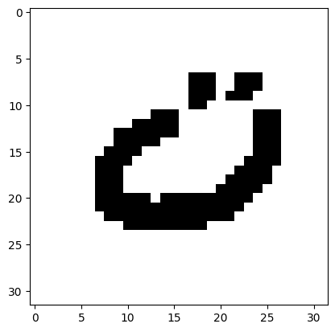

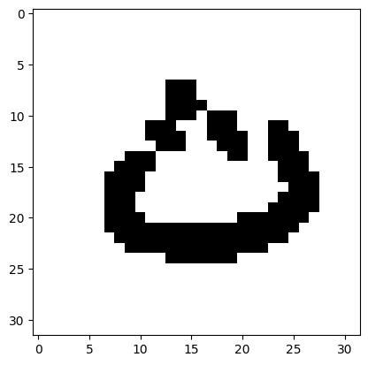

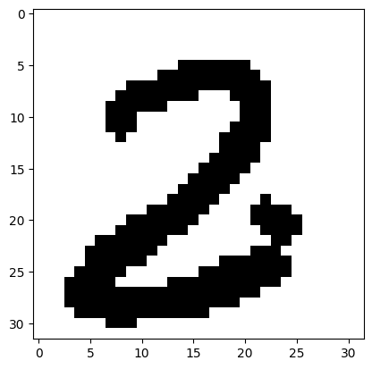

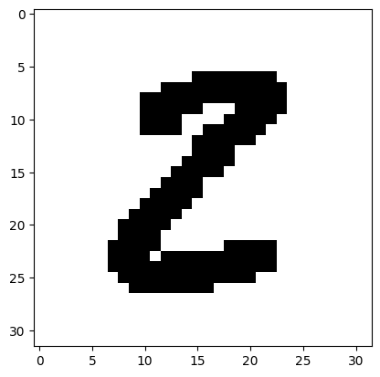

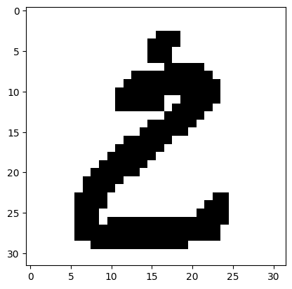

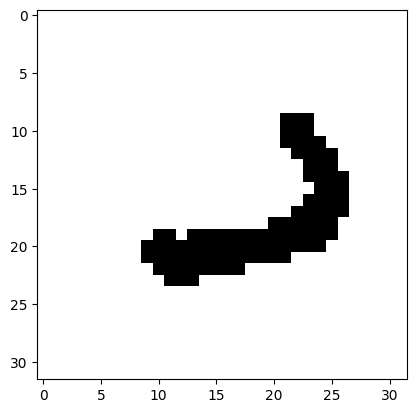

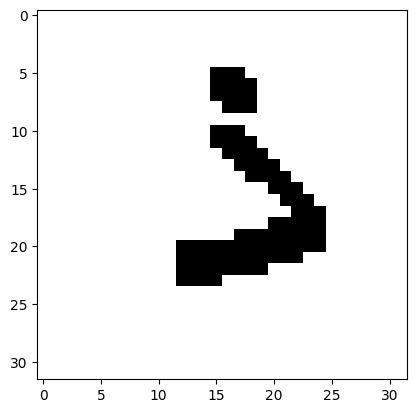

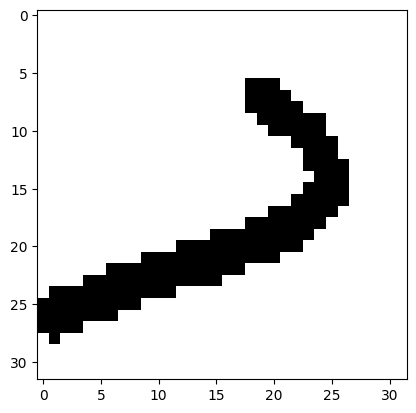

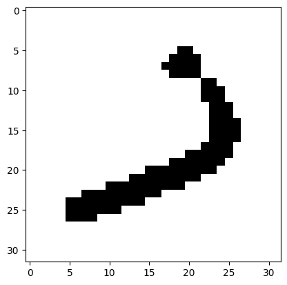

[figure not shown]

[3 more figures not shown]

```
1 0
```

```python
# fig = plt.figure(figsize=(16, 16))
images = []
for i in range(1, 16):
    img_arr = (df_train[df_train['Label'] == i]).apply(
        lambda x: np.array(x.iloc[:-1]).reshape(32, 32), axis=1)
    try:
        images.append(list(img_arr)[0])
    except:
        pass
for im in images:
    # fig.add_subplot(2,2,images.index(im))
    plt.imshow(im.transpose(), cmap='Greys')
    plt.show()
print(np.amax(images[0]), np.amin(images[0]))
```

# What does one hot encoding have to do with the latest layer?

The last layer predicts the class by passing the features and multipyling weights through them , since a single labels cannot be represented by a number (because scale matters), therefore we have to convert our lables into onehot vectors

```python
from sklearn.preprocessing import OneHotEncoder
from sklearn.utils import shuffle
class Dataloader:
    '''
    This class prepares the dataset for the neural network.
    '''

    def __init__(self, data, labels, n_classes, batch_size=None, shuffle=False):
        '''
        This is the constructor. It gets dataset information and initializes the
        Dataloader class fields.
            Parameters:
                data: features your dataset in pandas.Dataframe format.
                labels: labels of your dataset in pandas.Dataframe format.
                n_classes: number of classes you have in your dataset.
                batch_size: the number of samples that will be propagated through the network.

                : boolean value indicating whether or not the dataset should be shuffled
        '''
        assert len(data) == len(labels)
        self.__n_classes = n_classes
        self.__batch_size = batch_size
        self.__shuffle = shuffle
        self.__data = data
        self.__onehot_labels = self.__onehot(labels, self.__n_classes)

    def __onehot(self, labels, n_classes):
        '''
        This private method gets labels and provides one_hot vectors of labels.
        For categorical variables where no such ordinal relationship exists,
        the integer encoding is not enough.
        In this case, a one-hot encoding can be applied to the integer representation.
        This is where the integer encoded variable is removed, and a new binary variable is
        added for each unique integer value.
        example:
            red,    green,    blue
            1,      0,        0
            0,      1,        0
            0,      0,        1
                Parameters:
                        label: lables of your dataset in pandas.Dataframe format.
                        n_classes: number of classes you have in your dataset.

                Returns:
                    onehot_vectors: onehot vectors of the labels
        '''
        onehot_vectors = pd.DataFrame(
            OneHotEncoder().fit_transform(labels).toarray())
        return onehot_vectors

    def __shuffle_dataset(self):
        '''
        This private method shuffles your dataset.
        It uses data and onehot_labels to shuffle them
        symmetrical.
        '''
        self.__data , self.__onehot_labels=shuffle(self.__data,self.__onehot_labels)

    def __iter__(self):
        '''
        The __iter__() function returns an iterator for the
        given object (array, set, tuple, etc., or custom objects).
        This will return your dataset in the batch_size given. This should
        be used to provide data for the neural network.
        '''

        if self.__shuffle:
            self.__shuffle_dataset()

        if self.__batch_size == None:
            yield (np.matrix(self.__data), np.matrix(self.__onehot_labels))
            return

        for idx in range(0, len(self.__data), self.__batch_size):
            yield (np.matrix(self.__data[idx:idx+self.__batch_size]),
                   np.matrix(self.__onehot_labels[idx:idx+self.__batch_size]))
```

# Activation Functions

```python
class Identical:
    '''
    This is the Identical activation function. This activation function just
    return the value it gets.
    '''

    def __init__(self):
        '''
        This is the constructor. It does not have any fields
        as a result, there is no need to do anything in the constructor.
        '''
        pass

    def __val(self, matrix):
        '''
        This private method gets a matrix and uses the activity function on that.
        As this is an identical activity function, it just
        returns np.matrix of the input.

            Parameters:
                matrix: np.matrix of values
            Returns:
                identical_value: np.matrix of input with float datatypes
        '''
        identical_value = np.matrix(matrix, dtype=float)
        return identical_value

    def derivative(self, matrix):
        '''
        This method returns the derivation of the input.
        As the derivation of x is one, this method returns
        a matrix of one with the shape of the input matrix.

            Parameters:
                matrix: np.matrix of values
            Returns:
                identical_derivative: np.matrix of ones with matrix shape
        '''
        temp = np.matrix(matrix, dtype=float)
        identical_derivative = np.matrix(np.full(np.shape(temp), 1.))
        return identical_derivative

    def __call__(self, matrix):
        '''
        __call__ is a special function in Python that, when implemented inside a class,
        gives its instances (objects) the ability to behave like a function.
        Here we return the _value method output.

            Parameters:
                matrix: np.matrix of values
            Returns:
                __val(matrix): __val return value for the input matrix
        '''
        return self.__val(matrix)


class Relu:
    '''
    This is the Relu activation function.
    The rectified linear activation function or ReLU for short
    is a piecewise linear function that will output the input directly
    if it is positive, otherwise, it will output zero.
    '''

    def __init__(self):
        '''
        This is the constructor. It does not have any fields
        as a result, there is no need to do anything in the constructor.
        '''
        pass

    def __val(self, matrix):
        '''
        This private method gets a matrix and uses the activity function on that.
        It will set 0 in the matrix if the value is less than 0 else, it returns the value itself.

            Parameters:
                matrix: np.matrix of values
            Returns:
                relu_value: np.matrix of relu activation function result
        '''
        temp = np.matrix(matrix, dtype=float)
        relu_value = np.maximum(0, temp)
        return relu_value

    def derivative(self, matrix):
        '''
        Returns the derivation value of relu function on input matrix.

            Parameters:
                matrix: np.matrix of values
            Returns:
                relu_derivative: np.matrix of relu activation function derivation result
        '''
        temp = np.matrix(matrix, dtype=float)
        relu_derivative = np.matrix(
            np.full(np.shape(temp), np.where(temp >= 0, 1, 0)))
        return relu_derivative

    def __call__(self, matrix):
        '''
        __call__ is a special function in Python that, when implemented inside a class,
        gives its instances (objects) the ability to behave like a function.
        Here we return the _relu method output.

            Parameters:
                matrix: np.matrix of values
            Returns:
                __relu(matrix): __relu return value for the input matrix
        '''
        return self.__val(matrix)


class LeakyRelu:
    '''
    This is the Leaky Relu activation function.
    Leaky Rectified Linear Unit, or Leaky ReLU,
    is a type of activation function based on a ReLU,
    but it has a small slope for negative values instead
    of a flat slope.
    '''

    def __init__(self, negative_slope=0.01):
        '''
        This is the constructor.
        It sets negative_slope field.
            Parameters:
                negative_slope: slope for negative input values
        '''
        self.negative_slope = negative_slope

    def __val(self, matrix):
        '''
        This private method gets a matrix and uses the activity function on that.
        It will set negative_slope*value in the matrix if the value is less than 0, else it
        returns the value itself.

            Parameters:
                matrix: np.matrix of values
            Returns:
                relu_value: np.matrix of relu activation function result
        '''
        temp = np.matrix(matrix, dtype=float)
        return np.maximum(self.negative_slope * temp, temp)

    def derivative(self, matrix):
        '''
        Returns the derivation value of leaky relu function on input matrix.

            Parameters:
                matrix: np.matrix of values
            Returns:
                leacky_relu_derivative: np.matrix of leaky relu activation function derivation result
        '''
        temp = np.matrix(matrix, dtype=float)
        return np.matrix(
            np.where(temp > 0, 1, self.negative_slope))

    def __call__(self, matrix):
        '''
        __call__ is a special function in Python that, when implemented inside a class,
        gives its instances (objects) the ability to behave like a function.
        Here we return the _val method output.

            Parameters:
                matrix: np.matrix of values
            Returns:
                __val(matrix): __val return value for the input matrix
        '''
        return self.__val(matrix)


class Sigmoid:
    '''
    A sigmoid function is a mathematical function having a
    characteristic "S"-shaped curve or sigmoid curve.
    It return S(x)=1/(1+e^-x)
    '''

    def __init__(self):
        '''
        This is the constructor. It does not have any fields
        as a result, there is no need to do anything in the constructor.
        '''
        pass

    def __val(self, matrix):
        '''
        Returns 1/(1+e^-x) of values

            Parameters:
                matrix: np.matrix of values
            Returns:
                sigmoid_value: np.matrix of sigmoid activation function result
        '''
        temp = np.matrix(matrix, dtype=float)
        return 1/(1 + np.exp(-temp))

    def derivative(self, matrix):
        '''
        Returns the derivation value of sigmoid function on input matrix.

            Parameters:
                matrix: np.matrix of values
            Returns:
                sigmoid_derivative: np.matrix of sigmoid activation function derivation result
        '''
        matrix_copy = np.matrix(matrix, dtype=float)
        matrix_copy = self.__val(matrix_copy)
        sigmoid_derivative = np.multiply(matrix_copy, (1 - matrix_copy))
        return sigmoid_derivative

    def __call__(self, matrix):
        '''
        __call__ is a special function in Python that, when implemented inside a class,
        gives its instances (objects) the ability to behave like a function.
        Here we return the _val method output.

            Parameters:
                matrix: np.matrix of values
            Returns:
                __val(matrix): __val return value for the input matrix
        '''
        return self.__val(matrix)


class Softmax:
    '''
    The softmax function, also known as softargmax  or normalized
    exponential function is a generalization of the logistic
    function to multiple dimensions. It is used in multinomial logistic
    regression and is often used as the last activation function of a neural
    network to normalize the output of a network to a probability distribution
    over predicted output classes, based on Luce's choice axiom.
    Softmax return (e^x_i / (Σe^x_j for j = 1, ..., J))
    '''

    def __init__(self):
        '''
        This is the constructor. It does not have any fields
        as a result, there is no need to do anything in the constructor.
        '''
        pass

    def __val(self, matrix):
        '''
        This private method gets a matrix and uses the softmax on that.
        Softmax return (e^x_i / (Σe^x_j for j = 1, ..., J))

            Parameters:
                matrix: np.matrix of values
            Returns:
                softmax_value: np.matrix of softmax activation function result
        '''
        temp = np.matrix(matrix, dtype=float)
        softmax_value = np.apply_along_axis(lambda row: np.exp(
            row - np.max(row))/np.sum(np.exp(row - np.max(row))), 1, temp)
        return softmax_value

    def __call__(self, matrix):
        '''
        __call__ is a special function in Python that, when implemented inside a class,
        gives its instances (objects) the ability to behave like a function.
        Here we return the _val method output.

            Parameters:
                matrix: np.matrix of values
            Returns:
                __val(matrix): __val return value for the input matrix
        '''
        return self.__val(matrix)


class Tanh:
    '''
    tanh is also like logistic sigmoid but better.
    The range of the tanh function is from (-1 to 1).
    tanh is also sigmoidal (s - shaped).
    '''

    def __init__(self):
        '''
        This is the constructor. It does not have any fields
        as a result, there is no need to do anything in the constructor.
        '''
        pass

    def __val(self, matrix):  # check
        '''
        This private method gets a matrix and uses the activity function on that.
        It performs Tanh on the values.

            Parameters:
                matrix: np.matrix of values
            Returns:
                tanh_value: np.matrix of Tanh activation function result
        '''
        temp = np.matrix(matrix, dtype=float)
        tanh_value = np.tanh(temp)
        tanh_value = np.matrix(tanh_value)
        return tanh_value

    def derivative(self, matrix):
        '''
        Returns the derivation value of Tanh function on input matrix.

            Parameters:
                matrix: np.matrix of values
            Returns:
                sigmoid_derivative: np.matrix of Tanh activation function derivation result
        '''
        temp = np.matrix(matrix, dtype=float)
        tanh_derivative = 1 - np.power(self.__val(temp), 2)
        return tanh_derivative

    def __call__(self, matrix):
        '''
        __call__ is a special function in Python that, when implemented inside a class,
        gives its instances (objects) the ability to behave like a function.
        Here we return the _val method output.

            Parameters:
                matrix: np.matrix of values
            Returns:
                __val(matrix): __val return value for the input matrix
        '''
        return self.__val(matrix)
```


# Loss Function

```python
class CrossEntropy: #(with softmax)
    '''
    Cross-entropy is a measure of the difference between two probability
    distributions for a given random variable or set of events. You might
    recall that information quantifies the number of bits required to encode
    and transmit an event.
    The above image can help you.
    '''

    def __init__(self):
        pass
        '''
        This is the constructor. It does not have any fields
        as a result, there is no need to do anything in the constructor.
        '''

    def __val(self, true_val, expected_val):
        '''b
        L(y^, y) = - Σ (y^(k)log (y^)^(k)) for k in K
        Parameters:
            true_val: calculated values (generated by neural network)
            expected_val: real values in dataset
        Returns:
            cross_entropy_value: cross entropy of inputs
        '''
        assert np.shape(true_val)==np.shape(expected_val)
        # print(true_val,expected_val)
        cross_entropy_value = -1 * \
            np.sum(np.multiply(np.matrix(expected_val, dtype=float),
                   np.log(Softmax()(true_val))), axis=1)
        return cross_entropy_value

    def derivative(self, true_val, expected_val):
        '''
        Returns derivation of cross entropy.
            Parameters:
                true_val: calculated values (generated by neural network)
                expected_val: real values in dataset
            Returns:
                cross_entropy_derivative: cross entropy derivation of inputs
        '''
        assert np.shape(true_val) == np.shape(expected_val)

        temp = np.matrix(true_val, dtype=float)
        output = Softmax()(temp)
        expected = np.matrix(expected_val, dtype=float)

        cross_entropy_derivative = output - expected

        return cross_entropy_derivative


    def __call__(self, true_val, expected_val):
        '''
        __call__ is a special function in Python that, when implemented inside a class,
        gives its instances (objects) the ability to behave like a function.
        Here we return the _val method output.

            Parameters:
                true_val: calculated values (generated by neural network)
                expected_val: real values in dataset
            Returns:
                __val(matrix): __val return value for the input matrix
        '''
        return self.__val(true_val, expected_val)
```

# Layer

```python
class Layer:
    '''
    The layer class is used to define neural network layers.
    It stores all needed information for each layer, such as neurons count,
    weight matrix, bias, the output after applying the activation function, etc.
    '''

    DEFAULT_LOW, DEFAULT_HIGH, DEFAULT_MEAN, DEFAULT_VAR = 0, 0.05, 0., 1.

    def __init__(self, input_size, output_size, activation=Identical(), initial_weight='uniform',
                 **initializing_parameters):
        '''
        Parameters:
            input_size: the size of the input of this layer.
            output_size: the size of the output after this layer.
            activation: the activation function. It can be initialized to either of the previously defined activation classes.
                               default is an Identical activation function.
            initial_weight: either normal or uniform. It defines the method for weight initialization.
        '''

        assert type(initial_weight) == str, 'Undefined activation function!'

        self.__weight_initializer_dict = {'uniform': self.__uniform_weight,
                                          'normal': self.__normal_weight,
                                          }

        assert initial_weight in self.__weight_initializer_dict, 'Undefined weight initialization function!'

        self.__n_neurons = output_size
        weight_initializer = self.__weight_initializer_dict[initial_weight]
        self.__weight = weight_initializer(
            input_size, self.__n_neurons, **initializing_parameters)
        self.__bias = weight_initializer(
            1, self.__n_neurons, **initializing_parameters)
        self.__activation = activation

        self.__last_input = None
        self.__last_activation_input = None
        self.__last_activation_output = None
        self.__last_activation_derivative = None

    def forward(self, layer_input):
        '''
        It calculates the output of this layer for the layer_input argument.
        This method also stores __last_input, __last_activation_input, and __last_activation_derivative
        for future use in backpropagation.
        Parameters:
            layer_input: 2d np.matrix representing the input matrix of this layer.
        Returns:
            Final output of this layer after applying the activation function.
        '''
        assert np.ndim(layer_input) == 2
        assert np.size(self.__weight, 0) == np.size(layer_input, 1)

        self.__last_input = np.matrix(layer_input, dtype=float)
        self.__last_activation_input = np.add(
            self.__last_input@self.__weight, self.__bias)

        self.__last_activation_output = self.__activation(
            self.__last_activation_input)

        self.__last_activation_derivative = self.__activation.derivative(
            self.__last_activation_input)
        return self.__last_activation_output

    def update_weights(self, backprop_tensor, lr):
        '''
        It updates Layer weights according to the backpropagation matrix and learning rate.
        This method updates bias values as well.
        Parameters:
            backprop_tensor: 2d np.matrix passed from the next layer containing gradient values.
            lr: learning rate
        Returns:
            backprop_tensor to be used by the previous layer.
        '''
        assert np.ndim(backprop_tensor) == 2
        assert np.size(backprop_tensor, 0) == np.size(
            self.__last_activation_derivative, 0)
        assert np.size(backprop_tensor, 1) == self.__n_neurons

        ones = np.matrix(np.ones((np.size(backprop_tensor, axis=0), 1)))

        dy = np.multiply(backprop_tensor, self.__last_activation_derivative)
        db = np.matmul(ones.T, dy)
        dw = np.matmul(self.__last_input.T, dy)

        backprop_tensor = np.matmul(dy, np.transpose(self.__weight))

        self.__weight -= lr * dw
        self.__bias -= lr * db

        return backprop_tensor

    def __uniform_weight(self, dim1, dim2, **initializing_parameters):
        '''
        Initializes weights as a uniform distribution between low and high values.
        It uses default low and high values unless low or high are passed in initializing_parameters.
        Parameters:
            dim1: the size of the first dimension of weights.
            dim2: the size of the second dimension of weights.
            initializing_parameters: other initializing parameters; it can include custom low or high values.
        Returns:
            np.matrix with size (dim1, dim2) initialized using uniformly distributed values.
        '''
        low, high = self.DEFAULT_LOW, self.DEFAULT_HIGH
        if 'low' in initializing_parameters.keys():
            low = initializing_parameters['low']
        if 'high' in initializing_parameters.keys():
            high = initializing_parameters['high']

        weights = np.matrix(np.random.uniform(low, high, size=(dim1, dim2)))
        return weights

    def __normal_weight(self, dim1, dim2, **initializing_parameters):
        '''
        Initializes weights as a normal distribution with mean and var values.
        It uses default mean and variance values unless mean or var are passed in initializing_parameters.
        Parameters:
            dim1: the size of the first dimension of weights.
            dim2: the size of the second dimension of weights.
            initializing_parameters: other initializing parameters; it can include custom mean or var values.
        Returns:
            np.matrix with size (dim1, dim2) initialized using normaly distributed values.
        '''
        mean, var = self.DEFAULT_MEAN, self.DEFAULT_VAR
        if 'mean' in initializing_parameters.keys():
            mean = initializing_parameters['mean']
        if 'var' in initializing_parameters.keys():
            var = initializing_parameters['var']
        weights = np.matrix(np.random.normal(
            mean, np.sqrt(var), size=(dim1, dim2)))
        return weights

    @property
    def n_neurons(self): return self.__n_neurons

    @property
    def weight(self): return self.__weight

    @property
    def bias(self): return self.__bias

    @property
    def activation(self): return self.__activation
```

# Feed Forward Neural Network

```python
class FeedForwardNN:
    '''
    This class is used in order to implement custom feed-forward neural networks.
    The FeedForwardNN class stores a list of layers that determines all network layers.
    It also consists of the learning rate and loss function.
    '''
    def __init__(self, input_shape):
        '''
        Parameters:
            input_shape: the size of the first input to our neural network.
        '''

        self.__input_shape = input_shape
        self.__output_shape = None

        self.__layers_list = []

        self.__lr = None
        self.__loss = None


    def add_layer(self, n_neurons, activation=Relu(), initial_weight='uniform', **initializing_parameters):
        '''
         This method adds a new custom layer to the layers_list.
         Parameters:
             n_neurons: number of neurons in this layer
             activation: the activation function of this layer, default is Relu
             initial_weight: either a uniform or normal, default is uniform
             initializing_parameters: other initializing parameters such as low, high, mean, var, etc
        '''

        assert type(n_neurons)==int, "Invalid number of neurons for the layer!"
        assert n_neurons>0, "Invalid number of neurons for the layer!"

        n_prev_neurons = self.__input_shape if len(self.__layers_list)==0 else self.__layers_list[-1].n_neurons
        new_layer = Layer(n_prev_neurons, n_neurons, activation, initial_weight, **initializing_parameters)
        self.__layers_list.append(new_layer)
        self.__output_shape = self.__layers_list[-1].n_neurons


    def set_training_param(self, loss=CrossEntropy(), lr=1e-3):
        '''
        This method is used to set training parameters.
        Parameters:
            loss: loss function, default is CrossEntropy
            lr: learning rate, default is 1e-3
        '''
        assert self.__layers_list, "Uncomplete model!"
        self.__loss = loss
        self.__lr = lr


    def forward(self, network_input):
        '''
        This method calculates the output of the complete neural network for a passed input.
        Parameters:
            network_input: input of the neural network
        Returns:
            network_output: output of the neural network after forwarding the network_input
        '''
        assert type(self.__output_shape) != None, "Model is not compiled!"
        network_output = network_input
        for layer in self.__layers_list:
            # Update Network input each time we feed foward
            network_output = layer.forward(network_output)
        return network_output

    def fit(self, epochs, trainloader, testloader=None, print_results=True):
        '''
        This method trains the neural network using specified parameters.
        It runs the __train private method epoch times and fills the log dictionary.
        Parameters:
            epochs: number of epochs to run
            trainloader: DataLoader for train data
            testloader: DataLoader for test data
            print_results: whether or not to print the results
        Returns:
            log: complete log of the training process as a dictionary consisting of
            train_accuracy, train_loss, test_accuracy, test_loss
        '''

        assert type(self.__output_shape) != None, "Model is not compiled!"
        assert type(self.__lr) != None and type(self.__loss) != None, "Training paramenters are not set!"

        log = {"train_accuracy":[], "train_loss":[], "test_accuracy":[], "test_loss":[]}

        for epoch in range(1, epochs+1):

            if print_results:
                print('Epoch {}:'.format(epoch))

            average_accuracy, average_loss = self.__train(trainloader)
            log['train_accuracy'].append(average_accuracy)
            log['train_loss'].append(average_loss)
            if print_results:
                print('\tTrain: Average Accuracy: {}\tAverage Loss: {}'.format(average_accuracy, average_loss))

            if type(testloader) != type(None):
                average_accuracy, average_loss = self.__test(testloader)
                log['test_accuracy'].append(average_accuracy)
                log['test_loss'].append(average_loss)
                if print_results:
                    print('\tTest: Average Accuracy: {}\tAverage Loss: {}'.format(average_accuracy, average_loss))

        return log


    def __train(self, trainloader):
        '''
        Trains the neural network for one epoch.
        Parameters:
            trainloader: A DataLoader consisting of train data
        Returns:
            batch_accuracy, batch_loss: mean of all batch_accuracies, batch_losses
        '''
        bach_accuracies, batch_losses = [], []
        for x_train, y_train in trainloader:
            batch_accuracy, batch_loss = self.__train_on_batch(x_train, y_train)
            bach_accuracies.append(batch_accuracy)
            batch_losses.append(batch_loss)
        return np.mean(bach_accuracies), np.mean(batch_losses)


    def __test(self, testloader):
        '''
        Test the neural network using a testloader.
        Parameters:
            testloader: A DataLoader of test data
        Returns:
            batch_accuracy, batch_loss: mean of all batch_accuracies, batch_losses
        '''
        bach_accuracies, batch_losses = [], []
        for x_test, y_test in testloader:
            batch_accuracy, batch_loss = self.__test_on_batch(x_test, y_test)
            bach_accuracies.append(batch_accuracy)
            batch_losses.append(batch_loss)
        return np.mean(bach_accuracies), np.mean(batch_losses)


    def __train_on_batch(self, x_batch, y_batch):
        '''
        Trains the neural network for one batch of train data.
        Parameters:
            x_batch: one batch data
            y_batch: labels for one batch
        Returns:
            (batch_accuracy, batch_average_loss)
        '''
        network_output = self.forward(x_batch)
        batch_accuracy = self.__compute_accuracy(network_output, y_batch)
        batch_average_loss = np.mean(self.__loss(network_output, y_batch))

        self.__update_weights(network_output, y_batch)

        return (batch_accuracy, batch_average_loss)


    def __test_on_batch(self, x_batch, y_batch):
        '''
        Tests the neural network for one batch of test data.
        Parameters:
            x_batch: one batch data
            y_batch: labels for one batch
        Returns:
            (batch_accuracy, batch_average_loss)
        '''
        network_output = self.forward(x_batch)

        batch_accuracy = self.__compute_accuracy(network_output, y_batch)
        batch_average_loss = np.mean(self.__loss(network_output, y_batch))

        return (batch_accuracy, batch_average_loss)


    def __get_labels(self, outputs):
        '''
        Parameters:
            outputs: output of the neural network
        Returns:
            labels: labels generated from the outputs of the neural network
        '''
        return outputs.argmax(1)


    def __compute_accuracy(self, output, expected_output):
        '''
        Computes accuracy by comparing output and expected_output.
        Parameters:
            output: actual output of the neural network
            expected_output: expected output
        Returns:
            accuracy
        '''
        labels = self.__get_labels(output)
        expected_labels = self.__get_labels(expected_output)
        trues = labels == expected_labels
        accuracy = np.count_nonzero(
            trues) / np.size(output, axis=0) * 100
        return accuracy


    def __update_weights(self, output, y_train):
        '''
        Updates weights of all layers according to neural network output and labels.
        Parameters:
            output: output of the neural network
            y_train: y labels for one batch of train data
        Returns:
            None
        '''
        backpropagation_tensor = self.__loss.derivative(output, y_train)
        for layer in reversed(self.__layers_list):
            backpropagation_tensor = layer.update_weights(
                backpropagation_tensor, self.__lr)
        return
```

# Training Function

```python
pd.set_option('display.max_rows', 30)
```

```python
def Train_NN(y_train, X_train, X_test, y_test, layers, INPUT_SHAPE=32*32, LEARNING_RATE=0.005, EPOCHS=100, BATCH_SIZE=32, class_count=16):
    TRAINLOADER = [batch for batch in Dataloader(
        pd.DataFrame(X_train), pd.DataFrame(y_train), n_classes=class_count, batch_size=BATCH_SIZE, shuffle=True)]

    TESTLOADER = [batch for batch in Dataloader(
        pd.DataFrame(X_test), pd.DataFrame(y_test), n_classes=class_count, batch_size=BATCH_SIZE, shuffle=True)]

    network = FeedForwardNN(INPUT_SHAPE)

    for layer in layers:
        network.add_layer(layer[0], activation=layer[1],
                          weight_initializer='uniform')
    network.add_layer(class_count, activation=Identical(), weight_initializer='uniform')

    network.set_training_param(loss=CrossEntropy(), lr=LEARNING_RATE)

    resulting_network = network.fit(EPOCHS, TRAINLOADER, TESTLOADER)
```

# Third part Training the network

```python
y_train = df_train['Label']
X_train = df_train.drop(columns = ['Label'])
y_test = df_test['Label']
X_test = df_test.drop(columns=['Label'])

Train_NN(y_train,X_train,X_test,y_test,layers=[(128,Relu(),'normal')])
```

```
Epoch 1:
	Train: Average Accuracy: 18.766801075268816	Average Loss: 2.8482811830163826
	Test: Average Accuracy: 35.54435483870967	Average Loss: 1.926717190295394
Epoch 2:
	Train: Average Accuracy: 41.699008736559136	Average Loss: 1.6857116281731626
	Test: Average Accuracy: 48.413978494623656	Average Loss: 1.5022163310530405
Epoch 3:
	Train: Average Accuracy: 51.04880712365592	Average Loss: 1.3813035763502033
	Test: Average Accuracy: 55.5510752688172	Average Loss: 1.2999995040914853
Epoch 4:
	Train: Average Accuracy: 57.352990591397855	Average Loss: 1.195862072093012
	Test: Average Accuracy: 57.32358870967742	Average Loss: 1.191654797807207
Epoch 5:
	Train: Average Accuracy: 61.428511424731184	Average Loss: 1.0694334422467757
	Test: Average Accuracy: 60.34442204301076	Average Loss: 1.1213742300575082
Epoch 6:
	Train: Average Accuracy: 65.45110887096774	Average Loss: 0.9664200649997549
	Test: Average Accuracy: 62.84442204301076	Average Loss: 1.0708936252411383
Epoch 7:
	Train: Average Accuracy: 68.86340725806453	Average Loss: 0.8783211367562056
	Test: Average Accuracy: 63.83568548387097	Average Loss: 1.0545189399721218
Epoch 8:
	Train: Average Accuracy: 71.57174059139786	Average Loss: 0.8018148688686171
	Test: Average Accuracy: 64.77486559139784	Average Loss: 1.0271465835930707
Epoch 9:
	Train: Average Accuracy: 73.77310147849464	Average Loss: 0.7346165677108663
	Test: Average Accuracy: 65.92237903225806	Average Loss: 1.000714258048273
Epoch 10:
	Train: Average Accuracy: 76.05174731182797	Average Loss: 0.6751374394407563
	Test: Average Accuracy: 66.07862903225806	Average Loss: 1.00074257841085
Epoch 11:
	Train: Average Accuracy: 77.95236895161291	Average Loss: 0.6245910776468173
	Test: Average Accuracy: 66.90860215053763	Average Loss: 1.0164554641772043
Epoch 12:
	Train: Average Accuracy: 79.71102150537634	Average Loss: 0.5728796257114763
	Test: Average Accuracy: 68.57694892473118	Average Loss: 0.9790484173291548
Epoch 13:
	Train: Average Accuracy: 81.45623319892474	Average Loss: 0.5283362884972038
	Test: Average Accuracy: 68.36861559139786	Average Loss: 0.991297770948762
Epoch 14:
```

[output cut: 245 more lines]

```
Epoch 96:
	Train: Average Accuracy: 99.98697916666667	Average Loss: 0.0070296361501739485
	Test: Average Accuracy: 72.59912634408602	Average Loss: 1.7021326547336497
Epoch 97:
	Train: Average Accuracy: 99.98697916666667	Average Loss: 0.006886034887311054
	Test: Average Accuracy: 72.59912634408602	Average Loss: 1.704825575666898
Epoch 98:
	Train: Average Accuracy: 99.98697916666667	Average Loss: 0.006741600256025965
	Test: Average Accuracy: 72.59912634408602	Average Loss: 1.7090208638180837
Epoch 99:
	Train: Average Accuracy: 99.98697916666667	Average Loss: 0.0066280413523871935
	Test: Average Accuracy: 72.49495967741935	Average Loss: 1.7135690026633015
Epoch 100:
	Train: Average Accuracy: 99.98697916666667	Average Loss: 0.006502211630406583
	Test: Average Accuracy: 72.65120967741935	Average Loss: 1.7158138182600682
```

## Altering The Architecture

```python
Train_NN(y_train,X_train,X_test,y_test,layers=[
                                               (32,LeakyRelu(),'uninform'),
                                               (128,LeakyRelu(),'uniform'),
                                               ])
```

```
Epoch 1:
	Train: Average Accuracy: 9.507308467741934	Average Loss: 2.713010571027986
	Test: Average Accuracy: 11.82795698924731	Average Loss: 2.5373798305714828
Epoch 2:
	Train: Average Accuracy: 19.858870967741936	Average Loss: 2.2500135564331667
	Test: Average Accuracy: 23.605510752688172	Average Loss: 2.1326209695982428
Epoch 3:
	Train: Average Accuracy: 29.326696908602152	Average Loss: 1.9096251854778752
	Test: Average Accuracy: 33.340053763440864	Average Loss: 1.8648401878412832
Epoch 4:
	Train: Average Accuracy: 41.463793682795696	Average Loss: 1.5904358677431756
	Test: Average Accuracy: 47.46975806451613	Average Loss: 1.5590012065120504
Epoch 5:
	Train: Average Accuracy: 51.581821236559136	Average Loss: 1.29398233717155
	Test: Average Accuracy: 53.46606182795699	Average Loss: 1.3557929576971648
Epoch 6:
	Train: Average Accuracy: 58.05275537634408	Average Loss: 1.0896723344037256
	Test: Average Accuracy: 55.76108870967742	Average Loss: 1.3254149286847183
Epoch 7:
	Train: Average Accuracy: 62.15473790322581	Average Loss: 0.9626355445974847
	Test: Average Accuracy: 58.15860215053763	Average Loss: 1.184417884337688
Epoch 8:
	Train: Average Accuracy: 66.8443380376344	Average Loss: 0.8453926109432133
	Test: Average Accuracy: 61.544018817204304	Average Loss: 1.0366687666455783
Epoch 9:
	Train: Average Accuracy: 69.56569220430107	Average Loss: 0.7724083788468773
	Test: Average Accuracy: 64.62029569892474	Average Loss: 0.9949358564041936
Epoch 10:
	Train: Average Accuracy: 73.36819556451613	Average Loss: 0.6772218687345061
	Test: Average Accuracy: 64.51612903225806	Average Loss: 1.0453288735675443
Epoch 11:
	Train: Average Accuracy: 75.3599630376344	Average Loss: 0.6340163929159558
	Test: Average Accuracy: 66.49361559139784	Average Loss: 0.9917309596695314
Epoch 12:
	Train: Average Accuracy: 78.72059811827958	Average Loss: 0.5561916651367764
	Test: Average Accuracy: 68.37197580645162	Average Loss: 0.9613609966503844
Epoch 13:
	Train: Average Accuracy: 80.06216397849464	Average Loss: 0.5084965168163303
	Test: Average Accuracy: 68.89112903225806	Average Loss: 1.0119273568173162
Epoch 14:
```

[output cut: 245 more lines]

```
Epoch 96:
	Train: Average Accuracy: 100.0	Average Loss: 0.0004085794124688352
	Test: Average Accuracy: 79.05913978494624	Average Loss: 2.01873533812468
Epoch 97:
	Train: Average Accuracy: 100.0	Average Loss: 0.0003973739432562692
	Test: Average Accuracy: 79.05913978494624	Average Loss: 2.022452567890403
Epoch 98:
	Train: Average Accuracy: 100.0	Average Loss: 0.0003867834814619516
	Test: Average Accuracy: 79.05913978494624	Average Loss: 2.026225921155581
Epoch 99:
	Train: Average Accuracy: 100.0	Average Loss: 0.00037680514530628146
	Test: Average Accuracy: 79.05913978494624	Average Loss: 2.0302034020730475
Epoch 100:
	Train: Average Accuracy: 100.0	Average Loss: 0.000367349303955344
	Test: Average Accuracy: 79.11122311827958	Average Loss: 2.033806815057801
```

# Weighting the network

if we were to set all the weights as zero , back propagation would fail because the calculating the derivative results in 0 , therefore the gradient descent fails and the model does not converge

# Effect of Learning Rate

```python
Train_NN(y_train, X_train, X_test, y_test, layers=[
    (32, LeakyRelu(), 'uninform'),
    (128, LeakyRelu(), 'uniform'),
], LEARNING_RATE=0.008)
```

```
Epoch 1:
	Train: Average Accuracy: 11.030325940860216	Average Loss: 2.6346270717688336
	Test: Average Accuracy: 21.470094086021504	Average Loss: 2.2829075788778743
Epoch 2:
	Train: Average Accuracy: 27.37399193548387	Average Loss: 2.0036964093666962
	Test: Average Accuracy: 33.24260752688172	Average Loss: 1.766256360498471
Epoch 3:
	Train: Average Accuracy: 37.73899529569893	Average Loss: 1.6493546490853348
	Test: Average Accuracy: 44.60349462365591	Average Loss: 1.4704590392684795
Epoch 4:
	Train: Average Accuracy: 47.675151209677416	Average Loss: 1.3974450762978712
	Test: Average Accuracy: 53.775201612903224	Average Loss: 1.3047078773543466
Epoch 5:
	Train: Average Accuracy: 55.135668682795696	Average Loss: 1.173182562834976
	Test: Average Accuracy: 57.476478494623656	Average Loss: 1.1659249847625917
Epoch 6:
	Train: Average Accuracy: 60.215053763440864	Average Loss: 1.0339475912200549
	Test: Average Accuracy: 59.3010752688172	Average Loss: 1.0839350929301739
Epoch 7:
	Train: Average Accuracy: 64.39474126344086	Average Loss: 0.9232359740440226
	Test: Average Accuracy: 60.29233870967742	Average Loss: 1.1650638336519574
Epoch 8:
	Train: Average Accuracy: 67.65120967741935	Average Loss: 0.8355529557422443
	Test: Average Accuracy: 58.15524193548387	Average Loss: 1.1682346264145693
Epoch 9:
	Train: Average Accuracy: 69.80090725806453	Average Loss: 0.7960470925836167
	Test: Average Accuracy: 63.887768817204304	Average Loss: 1.0342686827317433
Epoch 10:
	Train: Average Accuracy: 72.44329637096774	Average Loss: 0.735084078991927
	Test: Average Accuracy: 64.61693548387096	Average Loss: 1.0168248838141483
Epoch 11:
	Train: Average Accuracy: 73.49840389784946	Average Loss: 0.6883248176788628
	Test: Average Accuracy: 64.46068548387096	Average Loss: 1.1671714943926432
Epoch 12:
	Train: Average Accuracy: 74.59131384408602	Average Loss: 0.6896601475200905
	Test: Average Accuracy: 61.48689516129033	Average Loss: 1.2868041861852018
Epoch 13:
	Train: Average Accuracy: 76.07694892473118	Average Loss: 0.6312699182378575
	Test: Average Accuracy: 64.6135752688172	Average Loss: 1.1526783114904944
Epoch 14:
```

[output cut: 245 more lines]

```
Epoch 96:
	Train: Average Accuracy: 91.03872647849464	Average Loss: 0.4357455751858352
	Test: Average Accuracy: 64.77318548387096	Average Loss: 4.479175338437743
Epoch 97:
	Train: Average Accuracy: 92.12155577956989	Average Loss: 0.3267314618978459
	Test: Average Accuracy: 70.45194892473118	Average Loss: 3.325886497091535
Epoch 98:
	Train: Average Accuracy: 93.02083333333333	Average Loss: 0.28045334942714567
	Test: Average Accuracy: 67.89986559139784	Average Loss: 3.379661478693177
Epoch 99:
	Train: Average Accuracy: 93.63197244623656	Average Loss: 0.2514869019169774
	Test: Average Accuracy: 69.46404569892474	Average Loss: 3.242938788874588
Epoch 100:
	Train: Average Accuracy: 91.63894489247312	Average Loss: 0.4330536141852214
	Test: Average Accuracy: 68.4190188172043	Average Loss: 3.664580548245222
```

```python
Train_NN(y_train, X_train, X_test, y_test, layers=[
    (32, LeakyRelu(), 'uninform'),
    (128, LeakyRelu(), 'uniform'),
], LEARNING_RATE=0.0001)
```

```
Epoch 1:
	Train: Average Accuracy: 6.446992607526882	Average Loss: 2.7526802927738063
	Test: Average Accuracy: 6.251680107526882	Average Loss: 2.7526035190542655
Epoch 2:
	Train: Average Accuracy: 6.486055107526882	Average Loss: 2.746900859403146
	Test: Average Accuracy: 6.251680107526882	Average Loss: 2.74865267077212
Epoch 3:
	Train: Average Accuracy: 6.460013440860215	Average Loss: 2.743342442078076
	Test: Average Accuracy: 6.251680107526882	Average Loss: 2.744713373708865
Epoch 4:
	Train: Average Accuracy: 6.525117607526882	Average Loss: 2.73978394138493
	Test: Average Accuracy: 6.251680107526882	Average Loss: 2.7407790034708897
Epoch 5:
	Train: Average Accuracy: 6.538138440860215	Average Loss: 2.7362186888707796
	Test: Average Accuracy: 6.251680107526882	Average Loss: 2.7368423824927013
Epoch 6:
	Train: Average Accuracy: 6.603242607526882	Average Loss: 2.7326394195179593
	Test: Average Accuracy: 6.251680107526882	Average Loss: 2.7328955432204376
Epoch 7:
	Train: Average Accuracy: 6.681367607526882	Average Loss: 2.7290380094800972
	Test: Average Accuracy: 6.251680107526882	Average Loss: 2.7289294248038596
Epoch 8:
	Train: Average Accuracy: 6.733450940860215	Average Loss: 2.7254051354692126
	Test: Average Accuracy: 6.251680107526882	Average Loss: 2.7249334680046924
Epoch 9:
	Train: Average Accuracy: 6.746471774193549	Average Loss: 2.7217298061107886
	Test: Average Accuracy: 6.251680107526882	Average Loss: 2.720895042002819
Epoch 10:
	Train: Average Accuracy: 6.785534274193549	Average Loss: 2.717998715714152
	Test: Average Accuracy: 6.251680107526882	Average Loss: 2.716798675764479
Epoch 11:
	Train: Average Accuracy: 6.850638440860215	Average Loss: 2.714195335357339
	Test: Average Accuracy: 6.251680107526882	Average Loss: 2.7126249044839947
Epoch 12:
	Train: Average Accuracy: 7.058971774193549	Average Loss: 2.7102985772858834
	Test: Average Accuracy: 6.251680107526882	Average Loss: 2.7083486315633807
Epoch 13:
	Train: Average Accuracy: 7.111055107526882	Average Loss: 2.7062808466067634
	Test: Average Accuracy: 6.251680107526882	Average Loss: 2.703936639027459
Epoch 14:
```

[output cut: 245 more lines]

```
Epoch 96:
	Train: Average Accuracy: 51.777973790322584	Average Loss: 1.4687479800030407
	Test: Average Accuracy: 51.64146505376344	Average Loss: 1.4713266184121923
Epoch 97:
	Train: Average Accuracy: 51.973286290322584	Average Loss: 1.4633622037776461
	Test: Average Accuracy: 51.64146505376344	Average Loss: 1.4668536595313342
Epoch 98:
	Train: Average Accuracy: 52.129536290322584	Average Loss: 1.4579761075435478
	Test: Average Accuracy: 51.745631720430104	Average Loss: 1.4623770084130248
Epoch 99:
	Train: Average Accuracy: 52.402973790322584	Average Loss: 1.45256319049621
	Test: Average Accuracy: 51.849798387096776	Average Loss: 1.457922919674441
Epoch 100:
	Train: Average Accuracy: 52.481098790322584	Average Loss: 1.447126715386092
	Test: Average Accuracy: 51.95396505376344	Average Loss: 1.453495095317314
```

# TanH and Sigmoid suffer from the problem of Gradient Vanish

What happens is basically if we have multiple hidden layers , these functions suffer from vanishing gradient for small values and negative values, they are multiplied together in the back propagation these gradients become very small, therefore not resulting in a good result, Leaky RELU smooths out these problem by applying a logical value for small or negative values and therefore can help to accomodate the gradient vanish issue

# Advantage of LRelu over Relu

Training time improves with leaky relu as there are no zero slopes that slow gradient decsent and does not suffer from the same problem than the TanH and Sigmoid , therefore we can have learnign when the gradient derivative becomes negative Also because computation time for Relu and Leaky Relu's is a lot faster and simpler , we will have less time spent for continious function calcualtion and derivation

```python
Train_NN(y_train, X_train, X_test, y_test, layers=[
        (32, LeakyRelu(), 'uniform'),
        (64, LeakyRelu(), 'uniform'),
        (32, LeakyRelu(), 'uniform'),

    ])
```

```
Epoch 1:
	Train: Average Accuracy: 8.112819220430108	Average Loss: 2.720861456911196
	Test: Average Accuracy: 12.40255376344086	Average Loss: 2.5863768676536334
Epoch 2:
	Train: Average Accuracy: 12.058131720430108	Average Loss: 2.4945128424365115
	Test: Average Accuracy: 8.802083333333334	Average Loss: 2.5973443693957696
Epoch 3:
	Train: Average Accuracy: 14.154485887096774	Average Loss: 2.3726175318514415
	Test: Average Accuracy: 10.425067204301076	Average Loss: 2.4933312015527225
Epoch 4:
	Train: Average Accuracy: 17.568044354838708	Average Loss: 2.2515324643130605
	Test: Average Accuracy: 21.686827956989248	Average Loss: 2.1061802258145845
Epoch 5:
	Train: Average Accuracy: 23.180443548387096	Average Loss: 2.0472007847781475
	Test: Average Accuracy: 25.1747311827957	Average Loss: 1.9787022511327337
Epoch 6:
	Train: Average Accuracy: 27.569724462365592	Average Loss: 1.9492289794353685
	Test: Average Accuracy: 26.577620967741936	Average Loss: 1.9115399508160056
Epoch 7:
	Train: Average Accuracy: 32.987231182795696	Average Loss: 1.7956965615464293
	Test: Average Accuracy: 37.25638440860215	Average Loss: 1.679616102162467
Epoch 8:
	Train: Average Accuracy: 40.031922043010745	Average Loss: 1.6056115768660502
	Test: Average Accuracy: 38.20228494623656	Average Loss: 1.5735530122343093
Epoch 9:
	Train: Average Accuracy: 45.370883736559136	Average Loss: 1.4192643495374895
	Test: Average Accuracy: 45.23689516129033	Average Loss: 1.3953447837628907
Epoch 10:
	Train: Average Accuracy: 51.16641465053763	Average Loss: 1.2732861074368997
	Test: Average Accuracy: 52.58064516129033	Average Loss: 1.2095011938434024
Epoch 11:
	Train: Average Accuracy: 55.215053763440864	Average Loss: 1.1419961045637141
	Test: Average Accuracy: 59.09442204301076	Average Loss: 1.0865798441728072
Epoch 12:
	Train: Average Accuracy: 59.69590053763441	Average Loss: 1.0276286608656986
	Test: Average Accuracy: 59.46404569892473	Average Loss: 1.0974904347121008
Epoch 13:
	Train: Average Accuracy: 62.899865591397855	Average Loss: 0.939509171365588
	Test: Average Accuracy: 61.07694892473118	Average Loss: 1.0602298813367639
Epoch 14:
```

[output cut: 245 more lines]

```
Epoch 96:
	Train: Average Accuracy: 96.73135080645162	Average Loss: 0.1168139920878808
	Test: Average Accuracy: 72.23286290322581	Average Loss: 2.251481006397748
Epoch 97:
	Train: Average Accuracy: 95.53217405913979	Average Loss: 0.17005668331207038
	Test: Average Accuracy: 70.66364247311827	Average Loss: 2.29695892836496
Epoch 98:
	Train: Average Accuracy: 94.49092741935483	Average Loss: 0.18566032827250353
	Test: Average Accuracy: 69.46908602150538	Average Loss: 2.5333144219104624
Epoch 99:
	Train: Average Accuracy: 95.859375	Average Loss: 0.1372293092256984
	Test: Average Accuracy: 73.17036290322581	Average Loss: 2.040757566211193
Epoch 100:
	Train: Average Accuracy: 97.27822580645162	Average Loss: 0.1007442438142779
	Test: Average Accuracy: 71.34576612903226	Average Loss: 2.39877917897446
```

```python
Train_NN(y_train, X_train, X_test, y_test, layers=[
        (32, Tanh(), 'uniform'),
        (64, Tanh(), 'uniform'),
        (32, Tanh(), 'uniform'),

])
```

```
Epoch 1:
	Train: Average Accuracy: 6.485215053763441	Average Loss: 2.7839061946995036
	Test: Average Accuracy: 6.253360215053763	Average Loss: 2.7697836540978864
Epoch 2:
	Train: Average Accuracy: 6.992607526881721	Average Loss: 2.764961315745583
	Test: Average Accuracy: 12.194220430107526	Average Loss: 2.7361472725348586
Epoch 3:
	Train: Average Accuracy: 11.487315188172042	Average Loss: 2.500332430897838
	Test: Average Accuracy: 13.133400537634408	Average Loss: 2.3018187804286696
Epoch 4:
	Train: Average Accuracy: 15.054183467741934	Average Loss: 2.274353139487683
	Test: Average Accuracy: 17.039650537634408	Average Loss: 2.206992083597621
Epoch 5:
	Train: Average Accuracy: 20.511172715053764	Average Loss: 2.090567370020945
	Test: Average Accuracy: 24.74966397849462	Average Loss: 1.9557261561182104
Epoch 6:
	Train: Average Accuracy: 27.960769489247312	Average Loss: 1.8172562310769147
	Test: Average Accuracy: 32.10349462365591	Average Loss: 1.7417200843956877
Epoch 7:
	Train: Average Accuracy: 37.81880040322581	Average Loss: 1.5906773053902454
	Test: Average Accuracy: 36.898521505376344	Average Loss: 1.6631459916103497
Epoch 8:
	Train: Average Accuracy: 43.117859543010745	Average Loss: 1.4442857964249016
	Test: Average Accuracy: 39.816868279569896	Average Loss: 1.6138103217786786
Epoch 9:
	Train: Average Accuracy: 46.89600134408602	Average Loss: 1.3334332083011555
	Test: Average Accuracy: 43.66935483870967	Average Loss: 1.5219550918076037
Epoch 10:
	Train: Average Accuracy: 50.24193548387097	Average Loss: 1.2350972951942554
	Test: Average Accuracy: 46.17271505376344	Average Loss: 1.4777996015927966
Epoch 11:
	Train: Average Accuracy: 55.1129872311828	Average Loss: 1.128149918587258
	Test: Average Accuracy: 49.2926747311828	Average Loss: 1.4566442173387555
Epoch 12:
	Train: Average Accuracy: 59.20110887096774	Average Loss: 1.0311179764786897
	Test: Average Accuracy: 51.066868279569896	Average Loss: 1.3990571431948575
Epoch 13:
	Train: Average Accuracy: 62.99017137096774	Average Loss: 0.9281741716222903
	Test: Average Accuracy: 53.67439516129033	Average Loss: 1.3308674648840177
Epoch 14:
```

[output cut: 60 more lines]

[output not shown]

```python
Train_NN(y_train, X_train, X_test, y_test, layers=[
        (32, Sigmoid(), 'uniform'),
        (64, Sigmoid(), 'uniform'),
        (32, Sigmoid(), 'uniform'),
])
```

```
Epoch 1:
	Train: Average Accuracy: 6.069388440860215	Average Loss: 2.796493178482337
	Test: Average Accuracy: 6.255040322580645	Average Loss: 2.7901651922951918
Epoch 2:
	Train: Average Accuracy: 5.900117607526882	Average Loss: 2.7914025552177977
	Test: Average Accuracy: 6.255040322580645	Average Loss: 2.785397393585456
Epoch 3:
	Train: Average Accuracy: 5.652721774193549	Average Loss: 2.7867979201777615
	Test: Average Accuracy: 6.255040322580645	Average Loss: 2.7819314119580336
Epoch 4:
	Train: Average Accuracy: 5.743867607526882	Average Loss: 2.78346536740016
	Test: Average Accuracy: 6.255040322580645	Average Loss: 2.779483106558194
Epoch 5:
	Train: Average Accuracy: 5.678763440860215	Average Loss: 2.7811621975845506
	Test: Average Accuracy: 6.251680107526882	Average Loss: 2.7777044069053645
Epoch 6:
	Train: Average Accuracy: 5.717825940860215	Average Loss: 2.7795291297805806
	Test: Average Accuracy: 6.251680107526882	Average Loss: 2.776346490683035
Epoch 7:
	Train: Average Accuracy: 5.952200940860215	Average Loss: 2.7782844687059907
	Test: Average Accuracy: 6.251680107526882	Average Loss: 2.7752460149468234
Epoch 8:
	Train: Average Accuracy: 5.992103494623657	Average Loss: 2.777247529269881
	Test: Average Accuracy: 6.251680107526882	Average Loss: 2.774294065196938
Epoch 9:
	Train: Average Accuracy: 6.031165994623657	Average Loss: 2.77630971749681
	Test: Average Accuracy: 6.251680107526882	Average Loss: 2.7734166305225485
Epoch 10:
	Train: Average Accuracy: 6.12231182795699	Average Loss: 2.7754063716737254
	Test: Average Accuracy: 6.251680107526882	Average Loss: 2.7725628725758
Epoch 11:
	Train: Average Accuracy: 6.291582661290323	Average Loss: 2.7744983648949506
	Test: Average Accuracy: 6.251680107526882	Average Loss: 2.7716969017366564
Epoch 12:
	Train: Average Accuracy: 6.447832661290323	Average Loss: 2.773560238565941
	Test: Average Accuracy: 6.251680107526882	Average Loss: 2.770790855724218
Epoch 13:
	Train: Average Accuracy: 6.682207661290323	Average Loss: 2.7725712507506968
	Test: Average Accuracy: 6.251680107526882	Average Loss: 2.769818244095428
Epoch 14:
```

[output cut: 245 more lines]

```
Epoch 96:
	Train: Average Accuracy: 53.691196236559136	Average Loss: 1.1654005280008783
	Test: Average Accuracy: 42.83266129032258	Average Loss: 1.5519643180619982
Epoch 97:
	Train: Average Accuracy: 54.60265456989247	Average Loss: 1.14899613609755
	Test: Average Accuracy: 42.83266129032258	Average Loss: 1.5570406030092911
Epoch 98:
	Train: Average Accuracy: 55.539734543010745	Average Loss: 1.1327806895826895
	Test: Average Accuracy: 42.25806451612903	Average Loss: 1.5629249295864998
Epoch 99:
	Train: Average Accuracy: 56.25672043010753	Average Loss: 1.117345177450735
	Test: Average Accuracy: 42.62264784946237	Average Loss: 1.5682389176393108
Epoch 100:
	Train: Average Accuracy: 56.51713709677419	Average Loss: 1.1133803604523178
	Test: Average Accuracy: 43.56350806451613	Average Loss: 1.5663261745044532
```